# MPN Colonies Signatures Analysis

Nick Williams

18/04/2021

## Signatures

Firstly retrieve the trinucleotide counts

```r
stamp=format(Sys.Date(),"%Y%m%d")
#cspall=get_sigprofile("../../signatures/sigprofiler_results/just_colonies5000/SBS96/")
#csp=get_sigprofile("../../signatures/sigprofiler_results/just_colonies5000_NO_40/SBS96/")
##load("~/projects/cache/PDD.11mar20.Rdat")
#Already loaded PDD
countsc=readRDS("../data/colonymutcount.Rds")
head(countsc)
```

```
##         PD7271.0 PD7271.1 PD5182.0 PD5182.1 PD5182.5 PD5182.3 PD5182.2 PD5182.4
## A[C>A]A      605      112     1389       48       66       14      126        6
## A[C>A]C      296       67      626       41       77        5       53        3
## A[C>A]G       45       16      170       10       15        1        7        2
## A[C>A]T      271       50      620       23       42        6       46        3
## C[C>A]A      574       97     1375       41       62        8      134        7
## C[C>A]C      197       40      475       27       41        1       41        1
##         PD5163.0 PD5163.3 PD5163.1 PD5163.2 PD5847.0 PD5847.1 PD5847.3 PD5847.2
## A[C>A]A      635       13       38       78      195       49      263       63
## A[C>A]C      296       12       24       38       91       46      177       19
## A[C>A]G       71        0        7        3       18        3       25        6
## A[C>A]T      308        4       19       39       94       29      168       35
## C[C>A]A      686        9       44       75      231       40      188       65
## C[C>A]C      212        3       28       29       71       21      137       18
##         PD5179.0 PD5179.1 PD5179.2 PD6634.0 PD6634.1 PD9478.0 PD9478.1 PD9478.5
## A[C>A]A       47       39      563       20      159      151      279        4
## A[C>A]C       28       31      445        7      105       65      213        1
## A[C>A]G        6        2       90        5       31       16       37        0
## A[C>A]T       22       19      341        7       88       75      150        2
## C[C>A]A       46       33      521       17      167      153      232        7
## C[C>A]C       21       20      310        9       87       52      136        3
##         PD9478.3 PD9478.2 PD9478.4 PD6629.0 PD6629.1 PD6629.2 PD6629.6 PD6629.5
## A[C>A]A        1        6       23       15      227      139       23        9
## A[C>A]C        1        2        9        5      135       85       23        8
## A[C>A]G        1        0        4        3       36       36        3        2
## A[C>A]T        4        2        8        8      112       79       11        1
## C[C>A]A        6        3        9       20      256      144       26        8
## C[C>A]C        0        2       10        7       83       72        8        2
##         PD6629.4 PD6629.3 PD6646.0 PD6646.1 PD6646.5 PD6646.2 PD6646.4 PD6646.3
## A[C>A]A       13       14      253      146      112      409        5        7
## A[C>A]C       10        9      111       46       68      247        3        6
## A[C>A]G        1        2       22       11       16       57        0        1
## A[C>A]T        9        8      115       71       57      193        3        6
## C[C>A]A       14       22      267      141      104      373        5       12
## C[C>A]C        7       10       75       43       43      170        4        7
##         PD5117.0 PD5117.1 PD4781.0 PD4781.1 PD4781.2 PD5147.0 PD5147.1
## A[C>A]A      634      573       14      241       32       12      736
## A[C>A]C      362      307        9      237       39        8      661
## A[C>A]G       77       77        1       38        8        4      105
## A[C>A]T      314      302        5      149       25        5      460
## C[C>A]A      678      521       24      239       32        5      570
## C[C>A]C      256      222        5      137       19        4      219
```

We carried out de-novo signature extraction using sigprofiler. Two analyses were run, one where large samples were down-sampled and one where all the data was used. In both cases similar proportions were observed:

## Counts

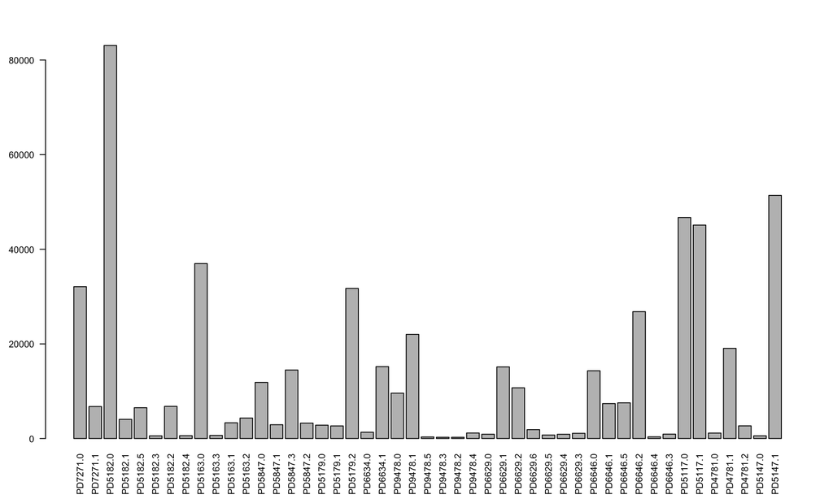

```r
## Firstly get description for samples
descdf=do.call("rbind",lapply(PDD,function(PD) data.frame(patient=rep(PD$patient,length(which(PD$nodes$node>=0))+1),
                                                          id=sprintf("%s.%s",PD$patient,0:length(PD$nodes$driver3[PD$nodes$node>=0])),
                                                            desc=c("WT",PD$nodes$driver3[PD$nodes$node>=0]))))
dp1=get_sigprofile("~/projects/t273/projects/MPN_REVISION/mpn_clonal_evolution_paper/signatures/colonies_ALL/SBS96")
dp2=get_sigprofile("~/projects/t273/projects/MPN_REVISION/mpn_clonal_evolution_paper/signatures/colonies5000r1/SBS96")

barplot(colSums(dp1$counts),las=2,cex.names = 1)
```

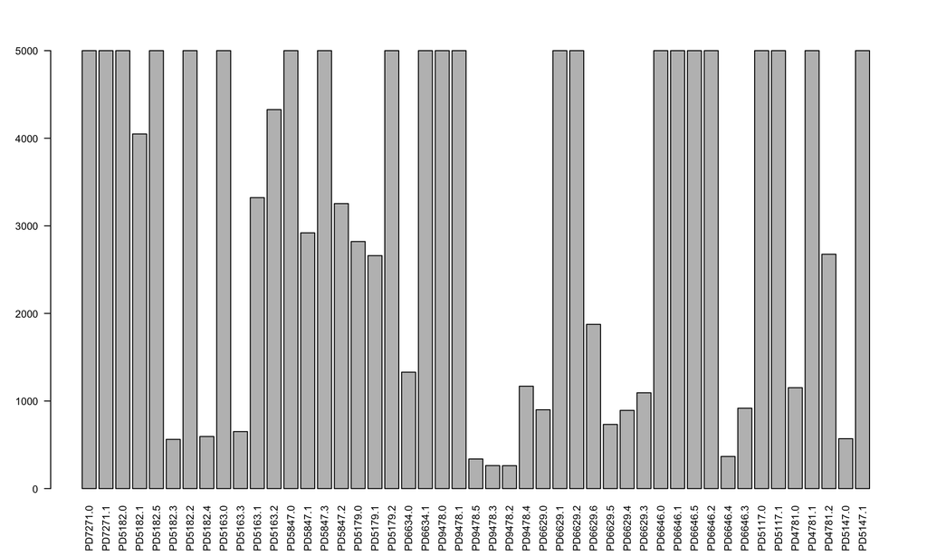

```r
barplot(colSums(dp2$counts),las=2,cex.names = 1)
```

## Sigprofiler Decomposed Solution

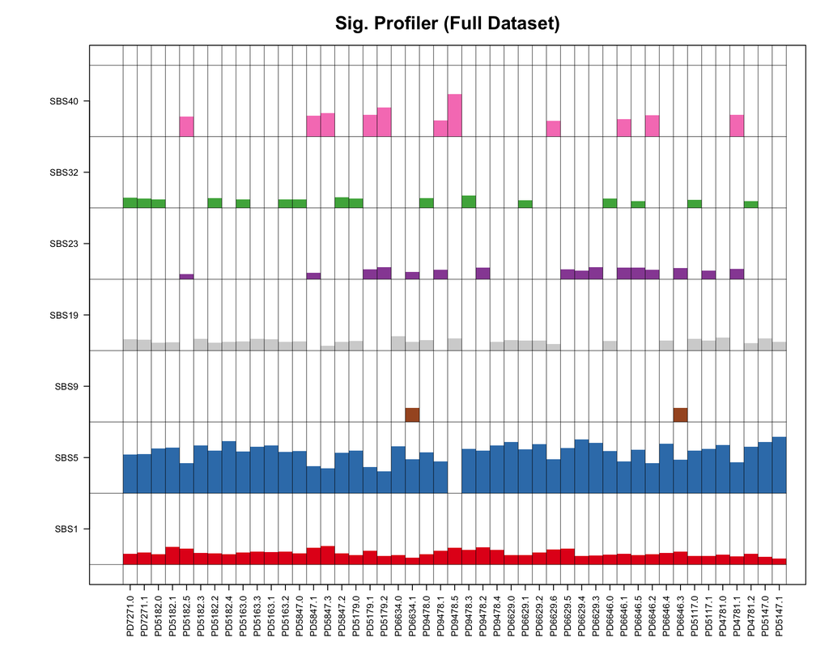

```r
expanded_plot(t(dp1$mean),title = "Sig. Profiler (Full Dataset)")
```

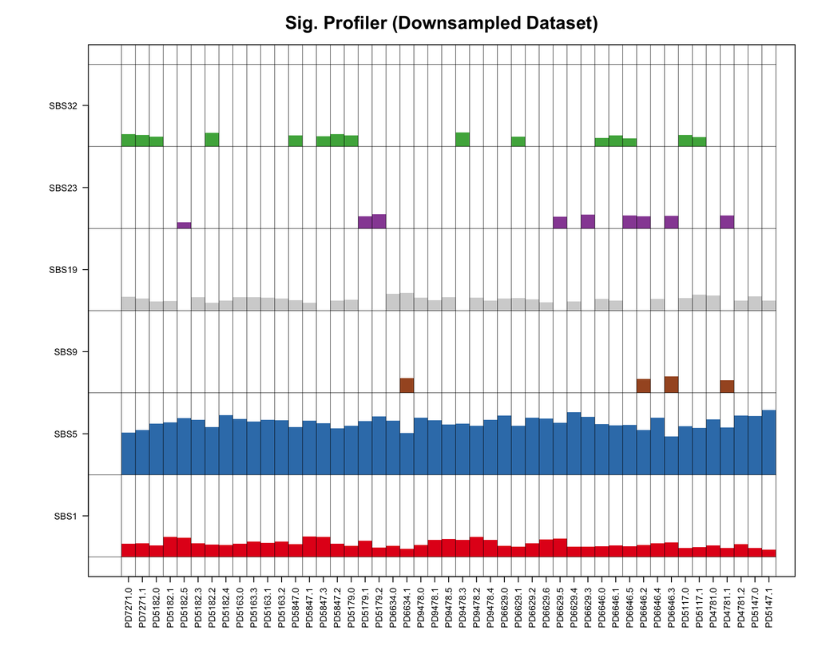

```r
expanded_plot(t(dp2$mean),title = "Sig. Profiler (Downsampled Dataset)")
```

## Full Signature Set and Reduced Signature Set

```r
esigs=c("SBS1","SBS5","SBS19","SBS23","SBS32","SBS9","SBS40")
sigs=c("SBS1","SBS5","SBS19","SBS32")
t2=fit_to_signatures(countsc,pcawg[,esigs])
t3=fit_to_signatures(countsc,pcawg[,sigs])
```

### Signature trinucleotide plots

Here we plot study wide signature contributions

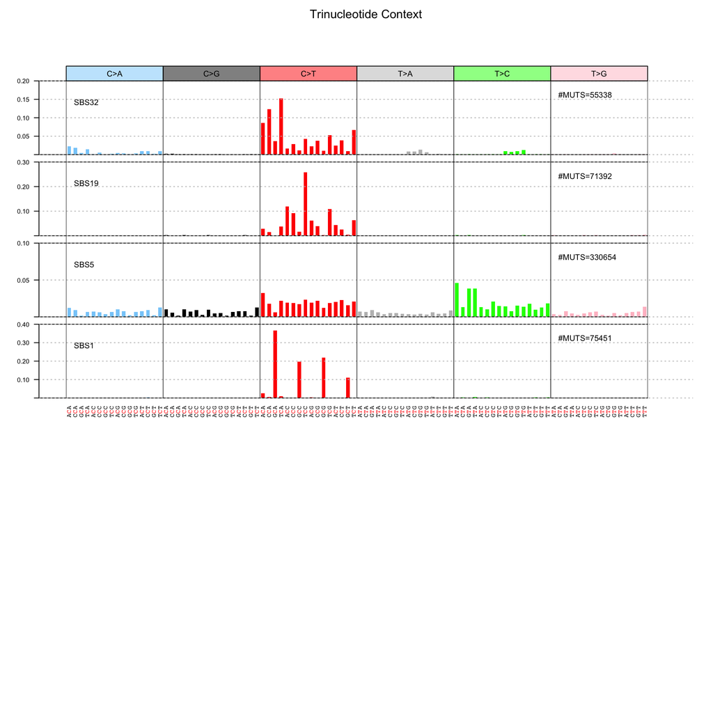

```r
sigmutprob=get_mutation_probability(pcawg[,sigs],t(t3$contribution))
sigcounts=pcawg[,sigs] * rep(rowSums(t3$contribution),each=96)
tmp=plot_96_sigs(sigcounts,ymax = ceiling(apply( sweep(sigcounts,MARGIN = 2,colSums(sigcounts),"/"),2,max)*10)/10,cex.labs = 1,NREF = 7)
```

Or for the bigger signature palette

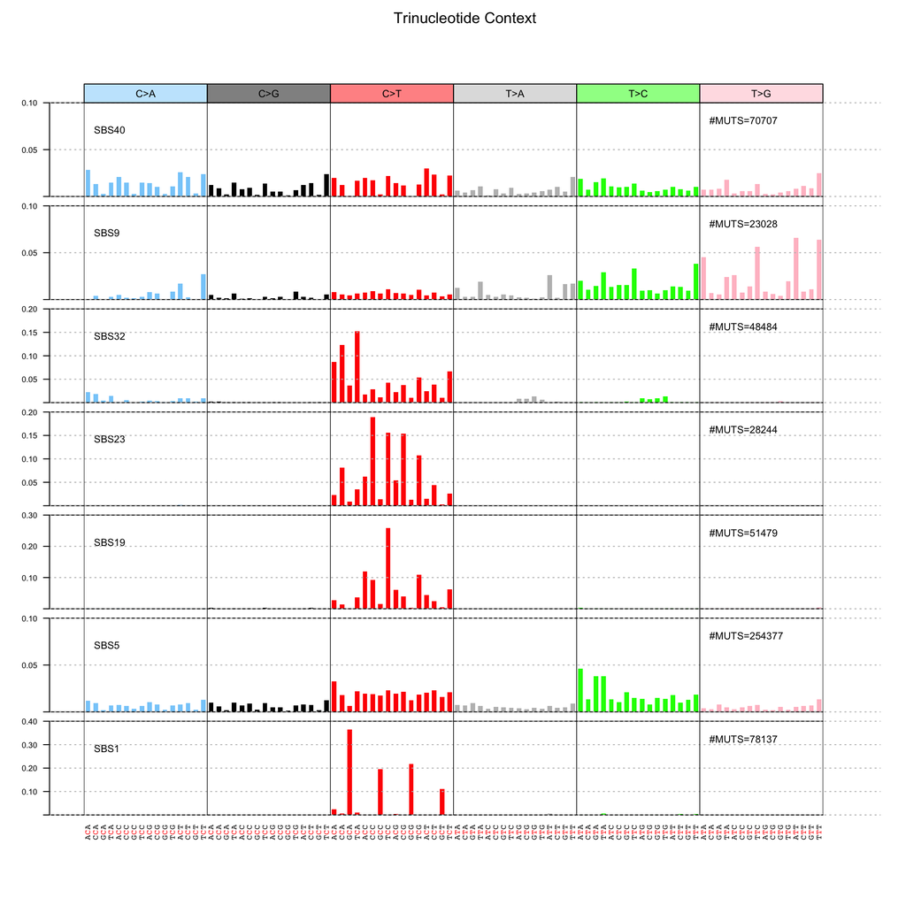

```r
sigmutprob=get_mutation_probability(pcawg[,esigs],t(t2$contribution))
sigcounts=pcawg[,esigs] * rep(rowSums(t2$contribution),each=96)
tmp=plot_96_sigs(sigcounts,ymax = ceiling(apply( sweep(sigcounts,MARGIN = 2,colSums(sigcounts),"/"),2,max)*10)/10,cex.labs = 1,NREF = 7)
```

Cosine similarities for the extended palette

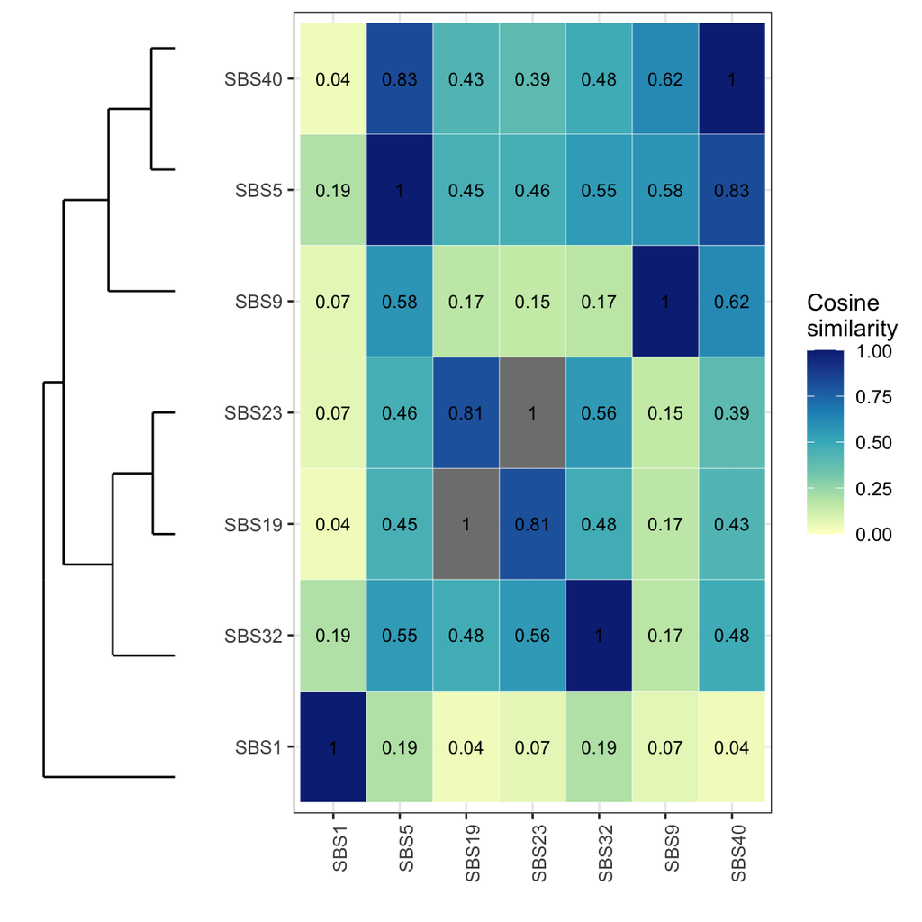

```r
csm=cos_sim_matrix(pcawg[,esigs],
                   pcawg[,esigs])
plot_cosine_heatmap(csm,plot_values = TRUE)
```

Aggregate signatures

```r
contragg=do.call("rbind",
                 lapply(
                   list(SBS1="SBS1",SBS_5_9_40=c("SBS5","SBS9","SBS40"),SBS_19_23=c("SBS19","SBS23"),SBS32="SBS32"),
                   function(x){if(length(x)>1){colSums(t2$contr[x,])}else{t2$contr[x,]}}
                   )
                 )
head(contragg)
```

```
##             PD7271.0  PD7271.1  PD5182.0  PD5182.1  PD5182.5  PD5182.3
## SBS1        4934.371 1158.3077 11881.226  965.0312 1397.0815  89.22365
## SBS_5_9_40 17806.192 3776.3188 52364.745 2388.5628 4279.4258 339.59304
## SBS_19_23   5188.139 1168.0821  8761.429  422.4888  443.2845  76.63825
## SBS32       4115.600  668.9765  9550.737  285.5959  314.7925  62.03255
##             PD5182.2  PD5182.4  PD5163.0  PD5163.3  PD5163.1  PD5163.2 PD5847.0
## SBS1       1061.1353  83.61916  6211.865 118.13094  560.8055  782.2445 1883.777
## SBS_5_9_40 4145.6215 380.14938 21926.624 393.87898 2028.8751 2524.8258 7059.432
## SBS_19_23   725.8454  66.20660  4600.131  87.69488  511.6069  558.7357 1518.701
## SBS32       860.4842  63.89442  4052.858  66.23928  222.0833  450.8115 1331.266
##             PD5847.1  PD5847.3  PD5847.2  PD5179.0  PD5179.1  PD5179.2 PD6634.0
## SBS1        687.0522 3656.9278  512.7824  372.1281  488.9477  3659.460 166.9460
## SBS_5_9_40 1782.6096 8973.3105 1872.4015 1683.4813 1612.5276 20463.703 756.5700
## SBS_19_23   236.7658  881.9038  381.4386  381.1593  336.4528  5144.275 228.9944
## SBS32       193.9692  794.8377  451.5998  318.4280  124.5182  1326.234 132.2711
##             PD6634.1 PD9478.0  PD9478.1  PD9478.5  PD9478.3  PD9478.2 PD9478.4
## SBS1       1415.3683 1373.424  4247.684  70.64663  52.71401  62.82978 230.4607
## SBS_5_9_40 9594.1967 5482.490 13409.583 208.62631 152.09393 156.26906 677.8628
## SBS_19_23  3089.8726 1378.415  2743.733  56.15091  13.21590  44.61371 110.6812
## SBS32       894.0496 1233.120  1421.955   0.00000  34.72435   0.00000 135.9734
##             PD6629.0 PD6629.1  PD6629.2  PD6629.6  PD6629.5  PD6629.4 PD6629.3
## SBS1       110.38102 1985.982 1747.0890  374.3660 158.53831 104.65534 137.2673
## SBS_5_9_40 569.32289 9225.769 6741.8262 1158.4169 419.56829 603.01698 715.4919
## SBS_19_23  105.16008 2327.519 1405.8444  166.0750 101.22758  87.98135 186.3144
## SBS32       86.05295 1280.945  649.5525  131.0051  42.02253  80.75313  58.6126
##            PD6646.0  PD6646.1  PD6646.5  PD6646.2  PD6646.4  PD6646.3  PD5117.0
## SBS1       1943.789 1053.8699  991.4796  3677.347  56.67398 156.72281  5600.383
## SBS_5_9_40 8534.353 4435.6689 4493.5866 17610.401 236.24044 555.33074 27811.718
## SBS_19_23  2086.960 1096.5164 1277.7606  3442.905  49.12986 133.64361  8160.138
## SBS32      1623.748  672.0533  720.0214  1669.471  16.40461  38.90558  4815.082
##             PD5117.1 PD4781.0   PD4781.1  PD4781.2  PD5147.0  PD5147.1
## SBS1        5156.771 150.9867  2058.3242  396.8366  56.73738  4095.097
## SBS_5_9_40 25491.403 655.6777 12810.7768 1730.5829 350.39921 37721.112
## SBS_19_23  10137.786 169.4265  2835.9290  296.4806  86.79750  6412.567
## SBS32       3572.600 151.4903   884.5959  207.3726  59.81606  2615.965
```

Calculate cosine similarities of the decomposition for the two different panels

```r
M=dim(countsc)[2]
csmlots=sapply(1:M,function(x) cos_sim(countsc[,x],t2$reconstructed[,x]))
csmfewer=sapply(1:M,function(x) cos_sim(countsc[,x],t3$reconstructed[,x]))
csm=data.frame(name=colnames(countsc),csmlots=csmlots,csmfewer=csmfewer,diff=csmlots-csmfewer)
print(csm)
```

```
##        name   csmlots  csmfewer         diff
## 1  PD7271.0 0.9839366 0.9823458 0.0015908577
## 2  PD7271.1 0.9859271 0.9804605 0.0054666327
## 3  PD5182.0 0.9846510 0.9835525 0.0010984995
## 4  PD5182.1 0.9858380 0.9826637 0.0031743455
## 5  PD5182.5 0.9836689 0.9744928 0.0091760806
## 6  PD5182.3 0.9617456 0.9602028 0.0015428301
## 7  PD5182.2 0.9778108 0.9760367 0.0017741736
## 8  PD5182.4 0.9594673 0.9579285 0.0015387824
## 9  PD5163.0 0.9820379 0.9811994 0.0008384109
## 10 PD5163.3 0.9547329 0.9508115 0.0039214874
## 11 PD5163.1 0.9842269 0.9821197 0.0021072654
## 12 PD5163.2 0.9801573 0.9783908 0.0017665099
## 13 PD5847.0 0.9830354 0.9819677 0.0010676810
## 14 PD5847.1 0.9864490 0.9800238 0.0064251929
```

[output cut: 33 more lines]

Mean difference in cosine similarity is:

```r
colMeans(csm[,-1])
```

```
##     csmlots    csmfewer        diff
## 0.972055671 0.965691617 0.006364055
```

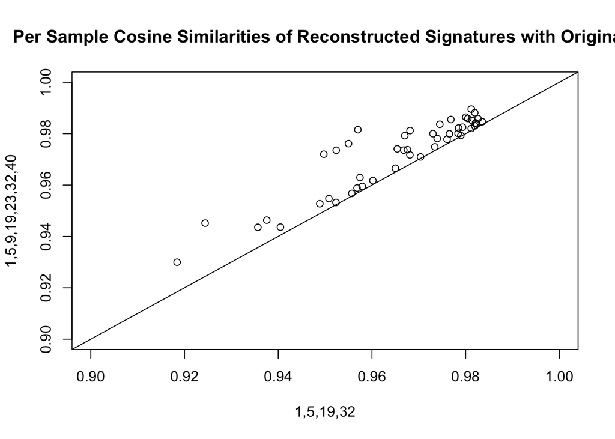

```r
plot(x=csmfewer,y=csmlots,xlim=c(0.9,1),ylim=c(0.9,1),ylab="1,5,9,19,23,32,40",xlab="1,5,19,32",main="Per Sample Cosine Similarities of Reconstructed Signatures with Originals")
abline(a=0,b=1)
```

The following illustrates how replacing SBS5, SBS9 and SBS40 by just SBS5 and SBS19, SBS23 by SB19 has very little effect on the other inferred signature contributions - compare the 2nd and 3rd of the following plots where the 2nd is simply an aggregation of the fitted signatures shown in the first plot whereas the 3rd plot shows the contributions when *just* the reduced signature set is fitted:

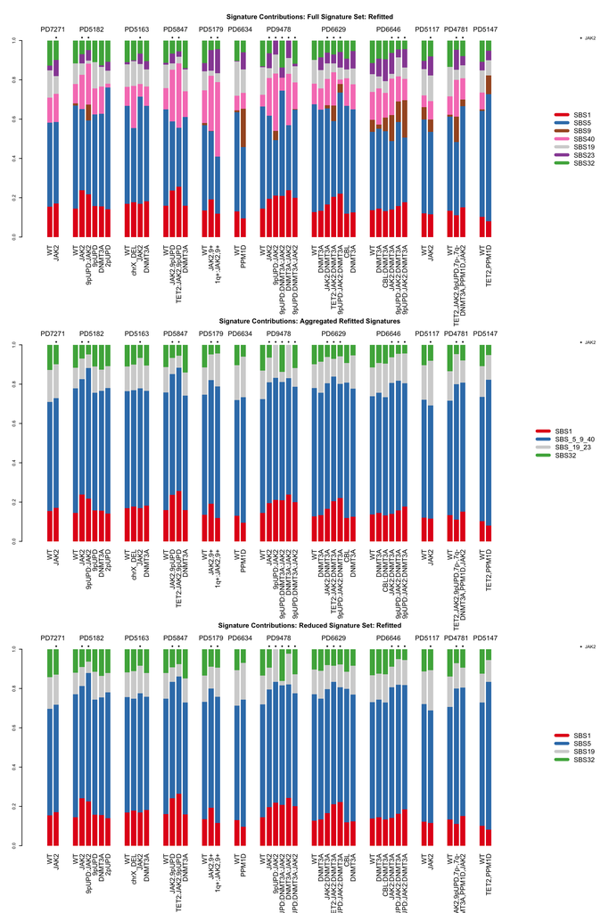

```r
par(mfcol=c(3,1))
do_stacked_plot(PDD,t2$contribution,"Signature Contributions: Full Signature Set: Refitted")
do_stacked_plot(PDD,contragg,"Signature Contributions: Aggregated Refitted Signatures")
do_stacked_plot(PDD,t3$contribution,"Signature Contributions: Reduced Signature Set: Refitted")
```

So the relative contributions of SB5,SB9 and SBS40 are unstable and so we going forward we represent these flat signatures by signature 5 which is known to be a pervasive clock-like signature.

### Trees

This shows the branch composition of the various clades on a per patient basis

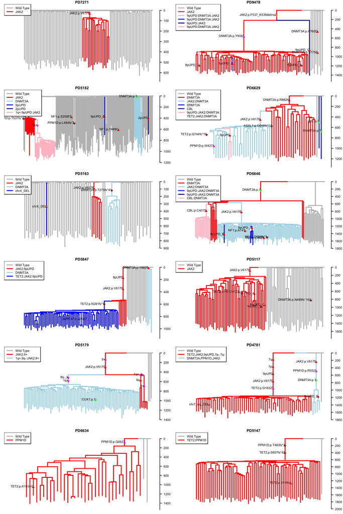

```r
par(mfcol=c(6,2))
cols=c("grey","red","lightblue","blue","darkblue","pink")
for(PD in PDD){
N=dim(PD$nodes)[1]
tmp=markup_tree(PD$pdx$tree_ml,PD$nodes$node[PD$nodes$status>=0])
PD$pdx$tree_ml$color=cols[tmp$type+1]
tree=plot_basic_tree(PD$pdx,label = PD$patient,style = "classic",cex.label=0,lwd=2,legpos = NULL)
legend("topleft",c("Wild Type",PD$nodes$driver3[PD$nodes$status>=0]),col=cols[1:(N+1)],lwd=2)
}
```

### C>T @ CpG

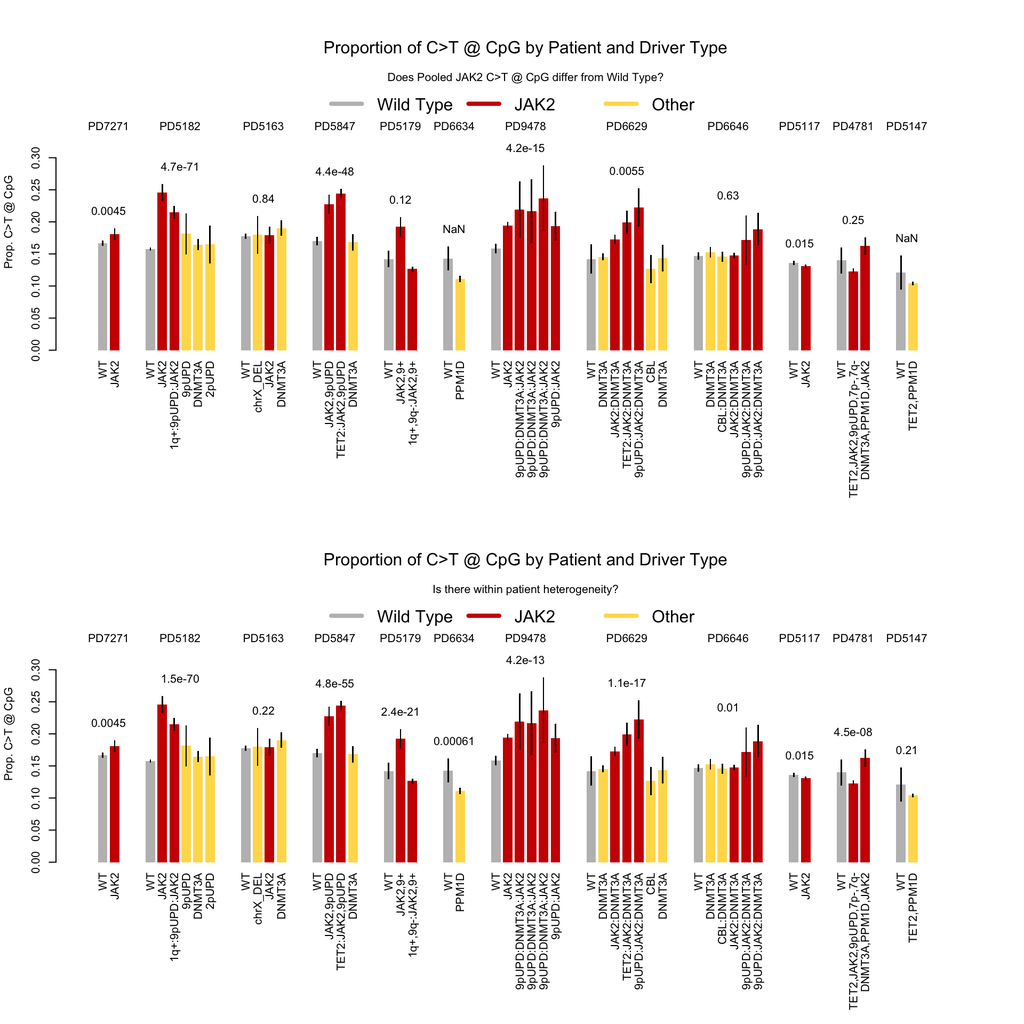

```r
par(mfcol=c(2,1))
#do_ctccpg_plot(PDD,countsc)
tmp=do_ctccpg_plot(PDD,countsc,b.show.p = TRUE)
#do_ctccpg_plot(PDD,countsc,b.jak2.v.wt = FALSE)
tmp=do_ctccpg_plot(PDD,countsc,b.jak2.v.wt = FALSE,b.show.p = TRUE)
```

The following contain also use Chi-square to test if JAK2 C>T @ CpG differs from WT but this time display the aggregated JAK2 counts

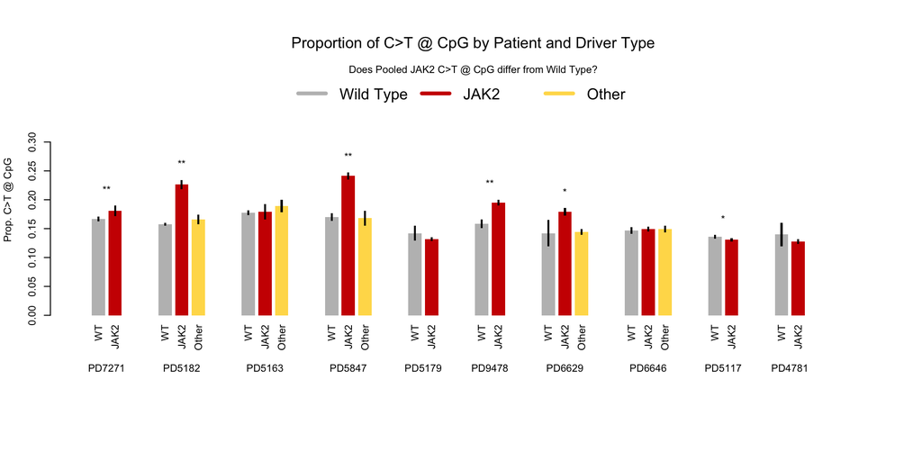

```r
res=do_ctccpg_plot_pooled(PDD,countsc,b.jak2.v.wt = TRUE,b.show.p = FALSE)
```

The counts are as follows:

```r
res=res[,1:4] %>% group_by(patient) %>%
    filter(status!="Other") %>% mutate(ct_at_cpg=ctsums,not_ct_at_cpg=csums-ctsums) %>%
    dplyr::select(-c("csums","ctsums")) %>%
    pivot_wider(names_from = "status",values_from=c("ct_at_cpg","not_ct_at_cpg")) %>%
    mutate(p.value=chisq.test(matrix(c(ct_at_cpg_WT, not_ct_at_cpg_WT, ct_at_cpg_JAK2,not_ct_at_cpg_JAK2),byrow=TRUE,ncol=2))$p.value) %>%
    ungroup() %>%
    mutate(p.value.bonf=p.adjust(p.value,method = "bonferroni"))
kable(res,"html") %>% kable_styling("striped")
```

| patient | ct_at_cpg_WT | ct_at_cpg_JAK2 | not_ct_at_cpg_WT | not_ct_at_cpg_JAK2 | p.value | p.value.bonf |
| --- | --- | --- | --- | --- | --- | --- |
| PD7271 | 5354 | 1225 | 26741 | 5537 | 0.0045082 | 0.0450816 |
| PD5182 | 13126 | 2393 | 69952 | 8172 | 0.0000000 | 0.0000000 |
| PD5163 | 6564 | 595 | 30412 | 2727 | 0.8369890 | 1.0000000 |
| PD5847 | 2019 | 4198 | 9838 | 13197 | 0.0000000 | 0.0000000 |
| PD5179 | 401 | 4530 | 2420 | 29857 | 0.1237706 | 1.0000000 |
| PD9478 | 1520 | 4698 | 8070 | 19348 | 0.0000000 | 0.0000000 |
| PD6629 | 128 | 2389 | 772 | 10937 | 0.0055371 | 0.0553706 |
| PD6646 | 2107 | 4187 | 12211 | 23917 | 0.6272721 | 1.0000000 |
| PD5117 | 6360 | 5894 | 40354 | 39217 | 0.0148125 | 0.1481251 |
| PD4781 | 161 | 2776 | 991 | 18959 | 0.2521362 | 1.0000000 |